# Case Study 1: Cyclistic

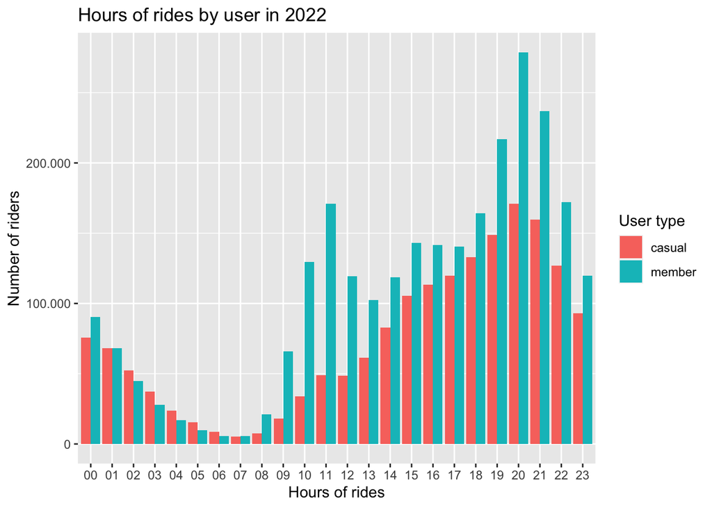

```r
hours %>%
    ggplot(aes(hour, number_of_rides, fill = user)) +
    geom_col(position = "dodge") +
    labs(
        title = "Hours of rides by user in 2022",
        x = "Hours of rides",
        y = "Number of riders",
        fill = "User type"
    )+
    scale_y_continuous(labels = comma_format(big.mark = ".",
                                           decimal.mark = ","))
```

Least popular bike usage time is between 02.00-08.00 which is home sleeping/resting time. Most popular bike usage time is 19.00-22.00

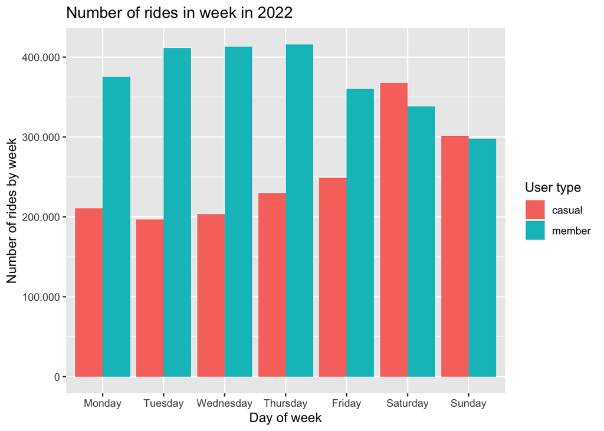

```r
# Find number of rides for each user

day_of_week_ %>%
    ggplot(aes(day_of_week, number_of_rides, fill = user)) +
    geom_col(position = "dodge") +
    labs(
        title = "Number of rides in week in 2022",
        x = "Day of week",
        y = "Number of rides by week",
        fill = "User type"
    )+
    scale_y_continuous(labels = comma_format(big.mark = ".",
                                           decimal.mark = ","))
```

# 7 Conlusion

Remember the questions we asked in the beginning. 1. How do annual members and casual riders use Cyclistic bikes differently? 2. Why would casual riders buy Cyclistic annual memberships? 3. How can Cyclistic use digital media to influence casual riders to become members?

#2 Annual members ride bikes almost everyday of the week.

#3 There can be advertisent that show the advantages using bike weekend and in longer journeys.

Thus, casual users could be encouraged buying annual plan.